# Uso del tiempo de los ecuatorianos 2

Christian Javier Salas Marquez

Marzo de 2022

Work in progress

Last edited: 12-04-2022

En este script se busca comparar los resultados de la pregunta: En la semana pasada… ¿Hizo ejercicios o practicó algún deporte? Tanto en la encuesta de uso del tiempo del 2012 como en la encuesta nacional multipropósito del 2020 se encuentra esta pregunta.

# Introducción

Según las recomendaciones de la OMS, las personas de 18 a 64 años de edad deberían realizar al menos 150 a 300 minutos (2.5 a 5 horas) de actividad física aeróbica moderada o 75 a 150 minutos (1.25 a 2.5 horas) de acitividad física aeróbica intensa en el transcurso de la semana.

En este artículo, vamos a calcular el promedio de horas semanales que los ecuatorianos dedican a hacer ejercicio o practicar deportes y ver cómo ha evolucionado este promedio comparando los resultados del año 2012 con los del 2020.

# 2012

# 2020

Se debe considerar también el tiempo de respuesta de los que responden que NO hicieron actividad física o deporte en la semana pasada, lo que implica que el encuestado realizó 0 horas de deporte, lo cual también influye en el promedio y debe considerarse.

## Resultados

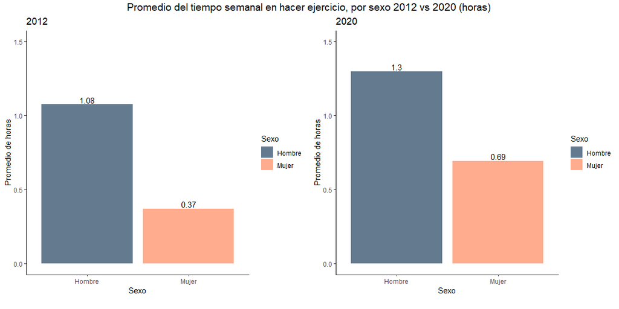

Se muestran dos gráficos que representan el promedio del tiempo semanal en hacer ejercicio o deportes por sexo. El gráfico de la izquierda es para el año 2012 y el de la derecha para el año 2020. Para el resto de visualizaciones de este artículo se cumple el mismo orden.

En primer lugar, podemos ver que para el año 2012, los hombres dedicaron en promedio 1.08 horas semanales en hacer ejercicio o deportes mientras que las mujeres dedicaron 0.37 horas semanales. Por otro lado, para el año 2020, los hombres dedicaron en promedio 1.3 horas semanales en hacer ejercicio y las mujeres 0.69 horas semanales.

Es significa que, para el año 2020, se observa un aumento del promedio de horas semanales que los hombres y las mujeres dedican a hacer ejercicio.

En el caso de los hombres, el promedio de horas en hacer ejercicio aumentó de 1.08 en el 2012 a 1.3 en el 2020. Para las mujeres, el promedio de horas semanal en hacer ejercicio aumentó de 0.37 en el 2012 a 0.69 en el 2020.

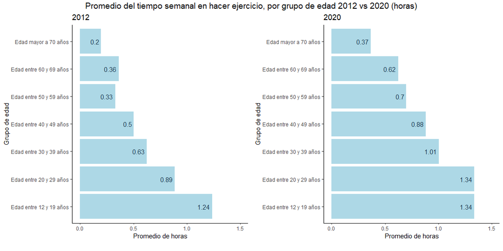

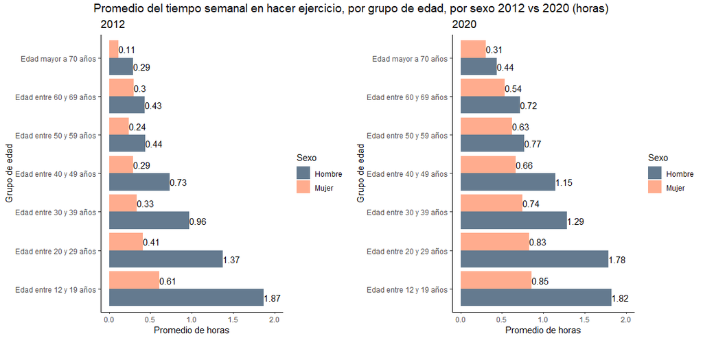

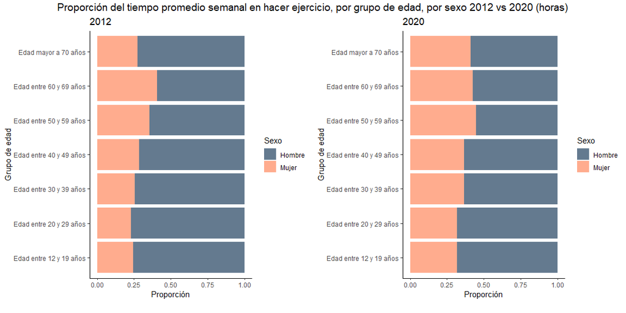

Esta visualización nos permite descubrir que en todos los grupos de edad considerados, tanto en el 2012 como el 2020, los hombres dedican una mayor cantidad de horas semanales en hacer ejercicio o practicar deportes.

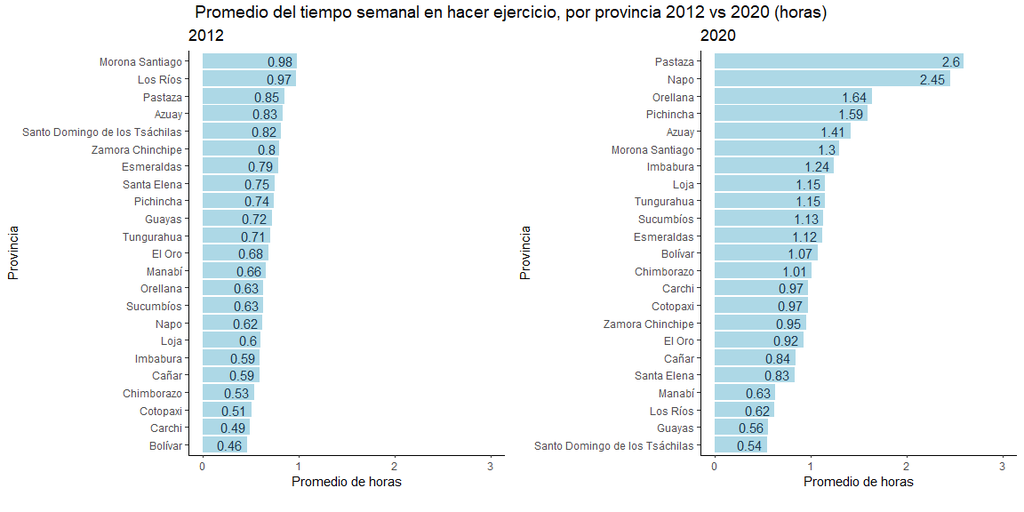

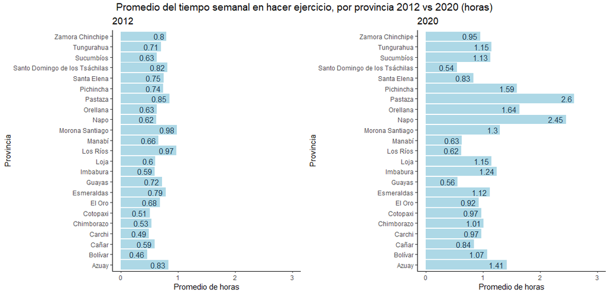

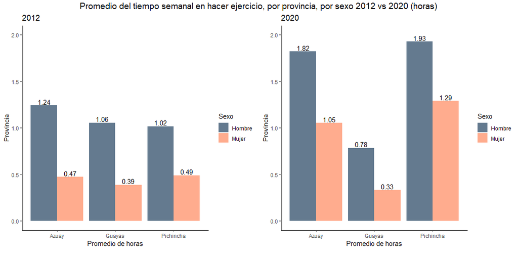

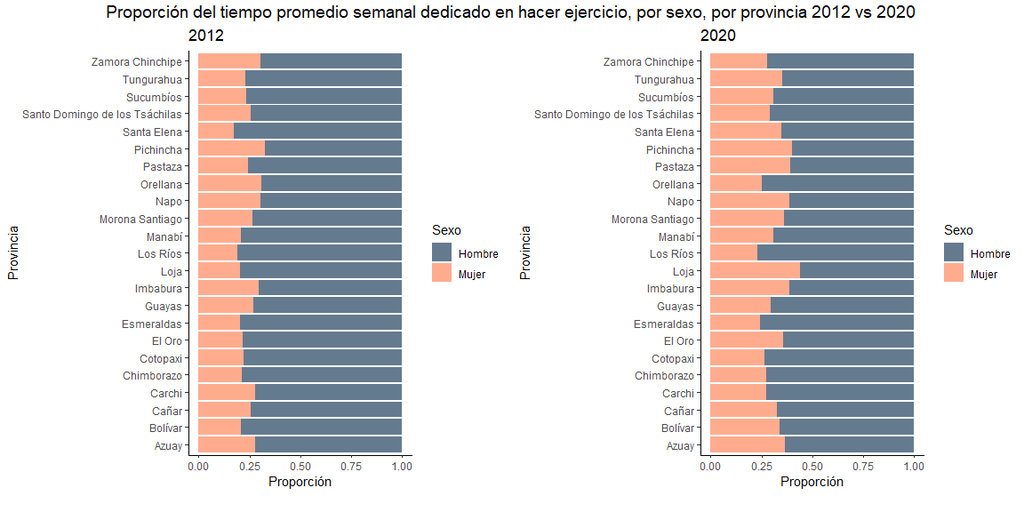

En este caso, observamos que en todas las provincias, los hombres en promedio dedican una mayor cantidad de horas semanales en hacer ejercicio o practicar deporte que las mujeres.

Referencias

Instituto Nacional de Estadística y Censos INEC. (2013). “Metodología de la Encuesta Específica de Uso del Tiempo - 2012.” Ecuador, Noviembre 2013. Recuperado de: https://www.ecuadorencifras.gob.ec//documentos/web-inec/Uso_Tiempo/Metodologia_EUT_2012.pdf

Instituto Nacional de Estadística y Censos INEC. (2012). “Encuesta específica de uso del tiempo EUT 2012” Ecuador, Noviembre 2012. Recuperado de: https://www.ecuadorencifras.gob.ec//documentos/web-inec/Uso_Tiempo/Formulario_2012.pdf

Instituto Nacional de Estadística y Censos INEC. (2012). “Encuesta específica de uso del tiempo EUT 2012” [base de datos]. Ecuador. Recuperado de: https://www.ecuadorencifras.gob.ec/uso-del-tiempo-2/#:~:text=Uso%20del%20Tiempo%20%E2%80%93%202012,y%20formulaci%C3%B3n%20de%20pol%C3%ADticas%20p%C3%BAblicas.

Instituto Nacional de Estadística y Censos INEC. (2020). “Documento metodológico de la Encuesta Nacional Multipropósito de Hogares (Seguimiento al Plan Nacional de Desarrollo)-2019” Ecuador, 2020. Recuperado de: https://www.ecuadorencifras.gob.ec/documentos/web-inec/Multiproposito/2019/201912_Metodologia_Multiproposito.pdf

Instituto Nacional de Estadística y Censos INEC. (2019). “Encuesta Nacional Multipropósito de Hogares-Diciembre-2019” Recuperado de: https://www.ecuadorencifras.gob.ec/documentos/web-inec/Multiproposito/2019/201912_Formulario_Multiproposito.pdf

Instituto Nacional de Estadística y Censos INEC. (2020). “Guia para el usuario de base de datos. Encuesta Nacional Multipropósito de Hogares (Seguimiento al Plan Nacional de Desarrollo)” Ecuador, junio 2020. Recuperado de: https://www.ecuadorencifras.gob.ec/documentos/web-inec/Multiproposito/2019/201912_%20Guia%20de%20usuario%20BDD_Multiproposito.pdf

Instituto Nacional de Estadística y Censos INEC. (2019). “Encuesta Nacional Multipropósito de Hogares (Seguimiento al Plan Nacional de Desarrollo)-2019” [base de datos]

https://www.who.int/es/news-room/fact-sheets/detail/physical-activity